# Supervised Learning - Foundations Project: ReCell

## Problem Statement

### Business Context

Buying and selling used phones and tablets used to be something that happened on a handful of online marketplace sites. But the used and refurbished device market has grown considerably over the past decade, and a new IDC (International Data Corporation) forecast predicts that the used phone market would be worth \$52.7bn by 2023 with a compound annual growth rate (CAGR) of 13.6% from 2018 to 2023. This growth can be attributed to an uptick in demand for used phones and tablets that offer considerable savings compared with new models.

Refurbished and used devices continue to provide cost-effective alternatives to both consumers and businesses that are looking to save money when purchasing one. There are plenty of other benefits associated with the used device market. Used and refurbished devices can be sold with warranties and can also be insured with proof of purchase. Third-party vendors/platforms, such as Verizon, Amazon, etc., provide attractive offers to customers for refurbished devices. Maximizing the longevity of devices through second-hand trade also reduces their environmental impact and helps in recycling and reducing waste. The impact of the COVID-19 outbreak may further boost this segment as consumers cut back on discretionary spending and buy phones and tablets only for immediate needs.

### Objective

The rising potential of this comparatively under-the-radar market fuels the need for an ML-based solution to develop a dynamic pricing strategy for used and refurbished devices. ReCell, a startup aiming to tap the potential in this market, has hired you as a data scientist. They want you to analyze the data provided and build a linear regression model to predict the price of a used phone/tablet and identify factors that significantly influence it.

### Data Description

The data contains the different attributes of used/refurbished phones and tablets. The data was collected in the year 2021. The detailed data dictionary is given below.

- brand_name: Name of manufacturing brand
- os: OS on which the device runs
- screen_size: Size of the screen in cm
- 4g: Whether 4G is available or not
- 5g: Whether 5G is available or not
- main_camera_mp: Resolution of the rear camera in megapixels
- selfie_camera_mp: Resolution of the front camera in megapixels
- int_memory: Amount of internal memory (ROM) in GB
- ram: Amount of RAM in GB
- battery: Energy capacity of the device battery in mAh
- weight: Weight of the device in grams
- release_year: Year when the device model was released
- days_used: Number of days the used/refurbished device has been used
- normalized_new_price: Normalized price of a new device of the same model in euros
- normalized_used_price: Normalized price of the used/refurbished device in euros

## Importing necessary libraries

```python
# Installing the libraries with the specified version.
# uncomment and run the following line if Google Colab is being used
#!pip install scikit-learn==1.2.2 seaborn==0.13.1 matplotlib==3.7.1 numpy==1.25.2 pandas==1.5.3 -q --user
```

```python
# Installing the libraries with the specified version.
# uncomment and run the following lines if Jupyter Notebook is being used
# !pip install scikit-learn==1.2.2 seaborn==0.11.1 matplotlib==3.3.4 numpy==1.24.3 pandas==1.5.2 -q --user
```

**Note**: *After running the above cell, kindly restart the notebook kernel and run all cells sequentially from the start again.*

```python
# Libraries to help with reading and manipulating data
import numpy as np
import pandas as pd

# Libraries to help with data visualization
import matplotlib.pyplot as plt
import seaborn as sns

sns.set()

# split the data into train and test
from sklearn.model_selection import train_test_split

# to build linear regression_model
from sklearn.linear_model import LinearRegression

# to check model performance
from sklearn.metrics import mean_absolute_error, mean_squared_error, r2_score

# to build linear regression_model using statsmodels
import statsmodels.api as sm

# to compute VIF
from statsmodels.stats.outliers_influence import variance_inflation_factor
```

## Loading the dataset

```python
# import drive from google colab
from google.colab import drive
drive.mount('/content/drive')
```

```python
 # loading data
data = pd.read_csv('/content/drive/My Drive/used_device_data.csv')
```

## Data Overview

- Observations
- Sanity checks

```python
# first five rows of the data set
data.head()
```

|  | brand_name | os | screen_size | 4g | 5g | main_camera_mp | selfie_camera_mp | int_memory | ram | battery | weight | release_year | days_used | normalized_used_price | normalized_new_price |
| --- | --- | --- | --- | --- | --- | --- | --- | --- | --- | --- | --- | --- | --- | --- | --- |
| 0 | Honor | Android | 14.50 | yes | no | 13.0 | 5.0 | 64.0 | 3.0 | 3020.0 | 146.0 | 2020 | 127 | 4.307572 | 4.715100 |
| 1 | Honor | Android | 17.30 | yes | yes | 13.0 | 16.0 | 128.0 | 8.0 | 4300.0 | 213.0 | 2020 | 325 | 5.162097 | 5.519018 |
| 2 | Honor | Android | 16.69 | yes | yes | 13.0 | 8.0 | 128.0 | 8.0 | 4200.0 | 213.0 | 2020 | 162 | 5.111084 | 5.884631 |
| 3 | Honor | Android | 25.50 | yes | yes | 13.0 | 8.0 | 64.0 | 6.0 | 7250.0 | 480.0 | 2020 | 345 | 5.135387 | 5.630961 |
| 4 | Honor | Android | 15.32 | yes | no | 13.0 | 8.0 | 64.0 | 3.0 | 5000.0 | 185.0 | 2020 | 293 | 4.389995 | 4.947837 |

```python
# shape of dataset
data.shape
```

```
(3454, 15)
```

**There are 3454 rows and 15 columns in the dataset.**

```python
# data types
data.info()
```

```
<class 'pandas.core.frame.DataFrame'>
RangeIndex: 3454 entries, 0 to 3453
Data columns (total 15 columns):
 #   Column                 Non-Null Count  Dtype
---  ------                 --------------  -----
 0   brand_name             3454 non-null   object
 1   os                     3454 non-null   object
 2   screen_size            3454 non-null   float64
 3   4g                     3454 non-null   object
 4   5g                     3454 non-null   object
 5   main_camera_mp         3275 non-null   float64
 6   selfie_camera_mp       3452 non-null   float64
 7   int_memory             3450 non-null   float64
 8   ram                    3450 non-null   float64
 9   battery                3448 non-null   float64
 10  weight                 3447 non-null   float64
 11  release_year           3454 non-null   int64
 12  days_used              3454 non-null   int64
 13  normalized_used_price  3454 non-null   float64
 14  normalized_new_price   3454 non-null   float64
dtypes: float64(9), int64(2), object(4)
memory usage: 404.9+ KB
```

### **Observation:**

- **Dateset contains a mix of numeric (11) and string (4) types in the columns.**

```python
 # statistical summary
data.describe(include='all').T
```

|  | count | unique | top | freq | mean | std | min | 25% | 50% | 75% | max |
| --- | --- | --- | --- | --- | --- | --- | --- | --- | --- | --- | --- |
| brand_name | 3454 | 34 | Others | 502 | NaN | NaN | NaN | NaN | NaN | NaN | NaN |
| os | 3454 | 4 | Android | 3214 | NaN | NaN | NaN | NaN | NaN | NaN | NaN |
| screen_size | 3454.0 | NaN | NaN | NaN | 13.713115 | 3.80528 | 5.08 | 12.7 | 12.83 | 15.34 | 30.71 |
| 4g | 3454 | 2 | yes | 2335 | NaN | NaN | NaN | NaN | NaN | NaN | NaN |
| 5g | 3454 | 2 | no | 3302 | NaN | NaN | NaN | NaN | NaN | NaN | NaN |
| main_camera_mp | 3275.0 | NaN | NaN | NaN | 9.460208 | 4.815461 | 0.08 | 5.0 | 8.0 | 13.0 | 48.0 |
| selfie_camera_mp | 3452.0 | NaN | NaN | NaN | 6.554229 | 6.970372 | 0.0 | 2.0 | 5.0 | 8.0 | 32.0 |
| int_memory | 3450.0 | NaN | NaN | NaN | 54.573099 | 84.972371 | 0.01 | 16.0 | 32.0 | 64.0 | 1024.0 |
| ram | 3450.0 | NaN | NaN | NaN | 4.036122 | 1.365105 | 0.02 | 4.0 | 4.0 | 4.0 | 12.0 |
| battery | 3448.0 | NaN | NaN | NaN | 3133.402697 | 1299.682844 | 500.0 | 2100.0 | 3000.0 | 4000.0 | 9720.0 |
| weight | 3447.0 | NaN | NaN | NaN | 182.751871 | 88.413228 | 69.0 | 142.0 | 160.0 | 185.0 | 855.0 |
| release_year | 3454.0 | NaN | NaN | NaN | 2015.965258 | 2.298455 | 2013.0 | 2014.0 | 2015.5 | 2018.0 | 2020.0 |
| days_used | 3454.0 | NaN | NaN | NaN | 674.869716 | 248.580166 | 91.0 | 533.5 | 690.5 | 868.75 | 1094.0 |
| normalized_used_price | 3454.0 | NaN | NaN | NaN | 4.364712 | 0.588914 | 1.536867 | 4.033931 | 4.405133 | 4.7557 | 6.619433 |
| normalized_new_price | 3454.0 | NaN | NaN | NaN | 5.233107 | 0.683637 | 2.901422 | 4.790342 | 5.245892 | 5.673718 | 7.847841 |

### **Observations:**

- **The mean prices of normalized used and normalized new are 4.4 euros and 5.2 euros respectively.**
- **Prices for normaliaed used ranges from 1.5 euros to 6.6 euros.**
- **Prices for normalized new ranges from 2.9 euros to 7.8 euros.**
- **Android is the top most operating system used.**
- **Most devices support 4g.**

```python
 # checking for duplicate values
data.duplicated().sum()
```

```
0
```

### **Observation:**

- **There are no duplicated values.**

```python
# checking for missing values
data.isnull().sum()
```

|  | 0 |
| --- | --- |
| brand_name | 0 |
| os | 0 |
| screen_size | 0 |
| 4g | 0 |
| 5g | 0 |
| main_camera_mp | 179 |
| selfie_camera_mp | 2 |
| int_memory | 4 |
| ram | 4 |
| battery | 6 |
| weight | 7 |
| release_year | 0 |
| days_used | 0 |
| normalized_used_price | 0 |
| normalized_new_price | 0 |

**dtype:** int64

### **Observations:**

- **There are 179 missing values for main camera, 2 missing for selfie camera, 4 each for internal memory and ram, 6 for battery and 7 for weight columns.**

```python
# total missing values
data.isnull().sum().sum()
```

```
202
```

### **Observation:**

- **There are 202 missing values in total.**

```python
# # copy of the original data to perform EDA on while maintaining the original dataset without any changes
data_eda = data.copy()
```

## Exploratory Data Analysis (EDA)

- EDA is an important part of any project involving data.
- It is important to investigate and understand the data better before building a model with it.
- A few questions have been mentioned below which will help you approach the analysis in the right manner and generate insights from the data.
- A thorough analysis of the data, in addition to the questions mentioned below, should be done.

**Questions**:

1. What does the distribution of normalized used device prices look like?
2. What percentage of the used device market is dominated by Android devices?
3. The amount of RAM is important for the smooth functioning of a device. How does the amount of RAM vary with the brand?
4. A large battery often increases a device's weight, making it feel uncomfortable in the hands. How does the weight vary for phones and tablets offering large batteries (more than 4500 mAh)?
5. Bigger screens are desirable for entertainment purposes as they offer a better viewing experience. How many phones and tablets are available across different brands with a screen size larger than 6 inches?
6. A lot of devices nowadays offer great selfie cameras, allowing us to capture our favorite moments with loved ones. What is the distribution of devices offering greater than 8MP selfie cameras across brands?
7. Which attributes are highly correlated with the normalized price of a used device?

## **UNIVARIATE ANALYSIS**

```python
# function to plot a boxplot and a histogram along the same scale.


def histogram_boxplot(data, feature, figsize=(15, 10), kde=False, bins=None):
    """
    Boxplot and histogram combined

    data: dataframe
    feature: dataframe column
    figsize: size of figure (default (15,10))
    kde: whether to show the density curve (default False)
    bins: number of bins for histogram (default None)
    """
    f2, (ax_box2, ax_hist2) = plt.subplots(
        nrows=2,  # Number of rows of the subplot grid= 2
        sharex=True,  # x-axis will be shared among all subplots
        gridspec_kw={"height_ratios": (0.25, 0.75)},
        figsize=figsize,
    )  # creating the 2 subplots
    sns.boxplot(
        data=data, x=feature, ax=ax_box2, showmeans=True, color="violet"
    )  # boxplot will be created and a triangle will indicate the mean value of the column
    sns.histplot(
        data=data, x=feature, kde=kde, ax=ax_hist2, bins=bins
    ) if bins else sns.histplot(
        data=data, x=feature, kde=kde, ax=ax_hist2
    )  # For histogram
    ax_hist2.axvline(
        data[feature].mean(), color="green", linestyle="--"
    )  # Add mean to the histogram
    ax_hist2.axvline(
        data[feature].median(), color="black", linestyle="-"
    )  # Add median to the histogram
```

```python
# function to create labeled barplots


def labeled_barplot(data, feature, perc=False, n=None):
    """
    Barplot with percentage at the top

    data: dataframe
    feature: dataframe column
    perc: whether to display percentages instead of count (default is False)
    n: displays the top n category levels (default is None, i.e., display all levels)
    """

    total = len(data[feature])  # length of the column
    count = data[feature].nunique()
    if n is None:
        plt.figure(figsize=(count + 2, 6))
    else:
        plt.figure(figsize=(n + 2, 6))

    plt.xticks(rotation=90, fontsize=15)
    ax = sns.countplot(
        data=data,
        x=feature,
        order=data[feature].value_counts().index[:n],
    )

    for p in ax.patches:
        if perc == True:
            label = "{:.1f}%".format(
                100 * p.get_height() / total
            )  # percentage of each class of the category
        else:
            label = p.get_height()  # count of each level of the category

        x = p.get_x() + p.get_width() / 2  # width of the plot
        y = p.get_height()  # height of the plot

        ax.annotate(
            label,
            (x, y),
            ha="center",
            va="center",
            size=12,
            xytext=(0, 5),
            textcoords="offset points",
        )  # annotate the percentage

    plt.show()  # show the plot
```

```python
# eliminating warnings
import warnings
warnings.filterwarnings("ignore")
```

### **Question 1**

### **NORMALIZED PRICE OF A USED DEVICE**

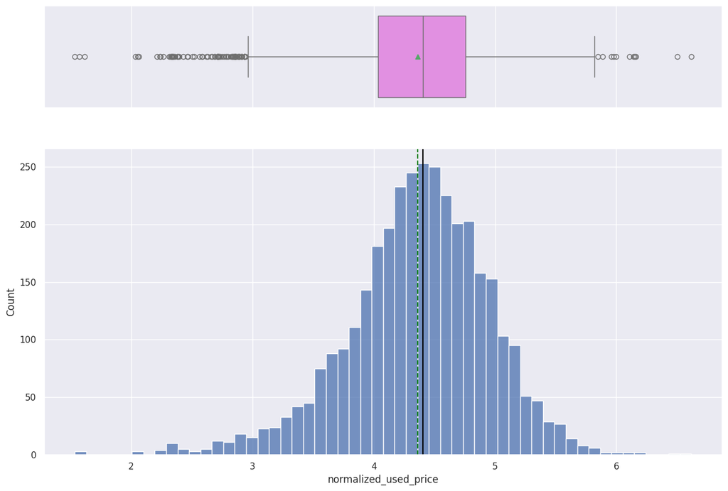

```python
# histogram and boxplot for normalized price of a used device
histogram_boxplot(data_eda, "normalized_used_price")
```

### **Observation**

- **Distribution is almost normal but slightly left skewed with lots of outliers.**
- **Medain is bit higher(almost equal) than the mean.**

### **NORMALIZED PRICE OF A NEW DEVICE (SAME MODEL)**

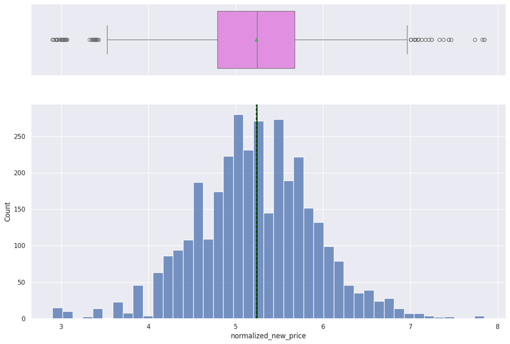

```python
# histogram and boxplot for normalized price of a new device
histogram_boxplot(data_eda, "normalized_new_price")
```

### **Observation:**

- **Distribution is very close to normal with outliers.**
- **Median and mean are almost the same.**

### **SCREEN SIZE**

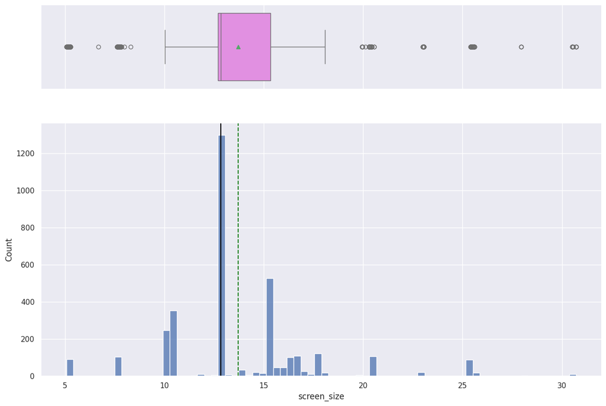

```python
# histogram and box plot for screen size
histogram_boxplot(data_eda, "screen_size")
```

### **Observations:**

- **Screen size distribution is right skewed with outliers at both ends of the boxplot**
- **Mean value for screen size is higher the median value.**

### **REAR CAMERA RESOLUTION**

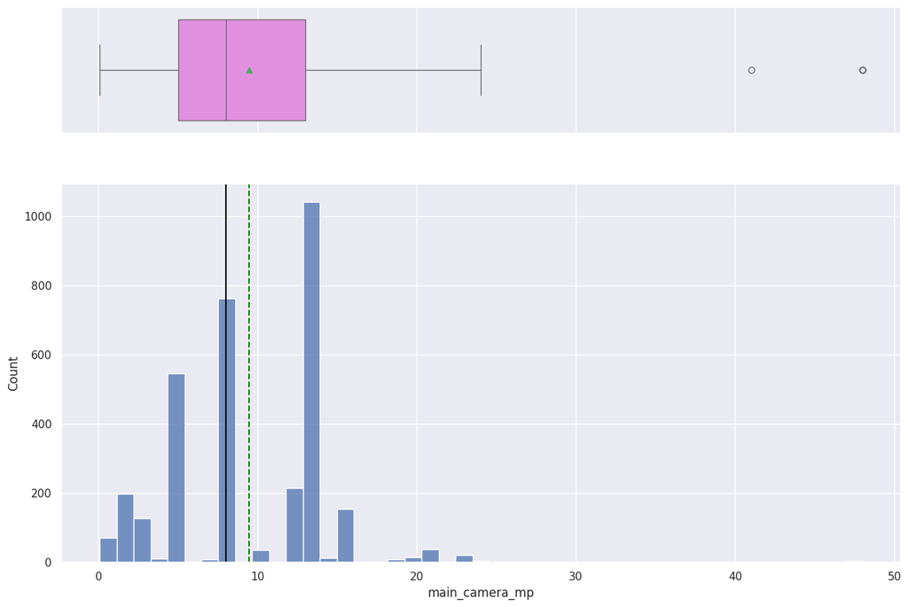

```python
# histogram and box plot for main (rear) camera
histogram_boxplot(data_eda, "main_camera_mp")
```

### **Observations:**

- **The distribution for rear camera resolution is right skewed with outliers.**

### **FRONT CAMERA RESOLUTION**

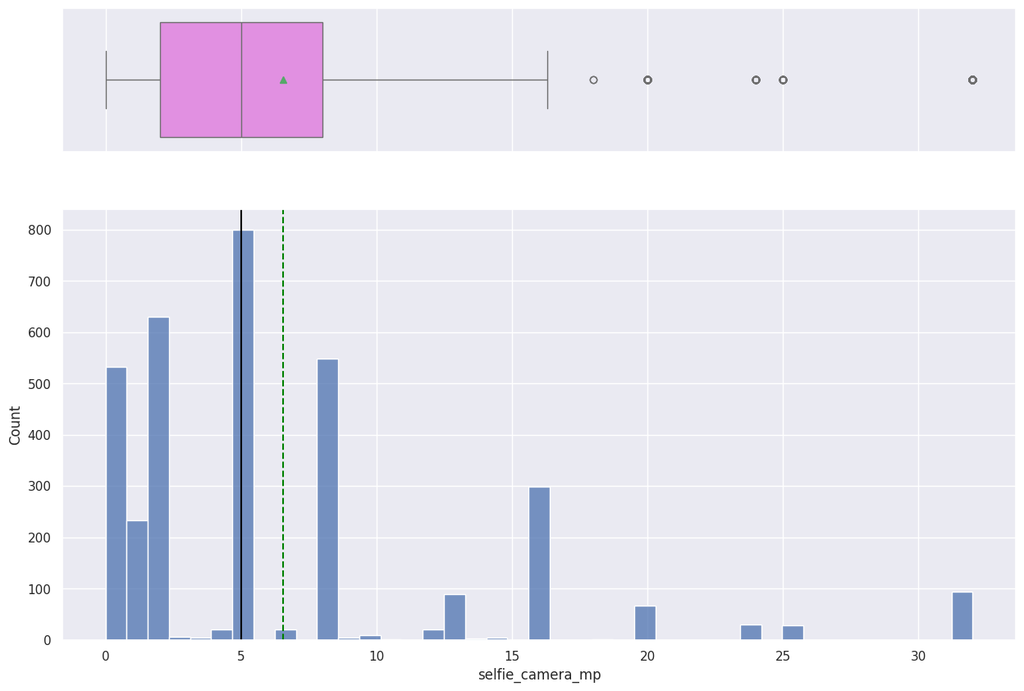

```python
# histogram and box plot for front(selfie) camera
histogram_boxplot(data_eda, "selfie_camera_mp")
```

### **Observations:**

- **Distribution for front(selfie) camera is heavily right skewed.**
- **Median is about 5 megapixels which is less than the mean of 6.6 megapixels.**
- **Devices with megapixels more than 8 are few.**

### **INTERNAL MEMORY**

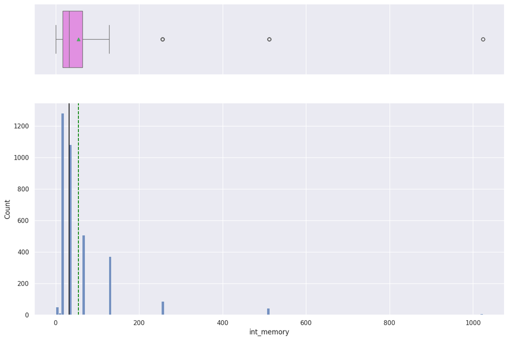

```python
# histogram and box plot for internal memory
histogram_boxplot(data_eda, "int_memory")
```

### **Observations:**

- **Distribution for internal memory is heavily skewed to the right with outliers.**
- **Mean for internal memory is higher than the median.**

### **RAM**

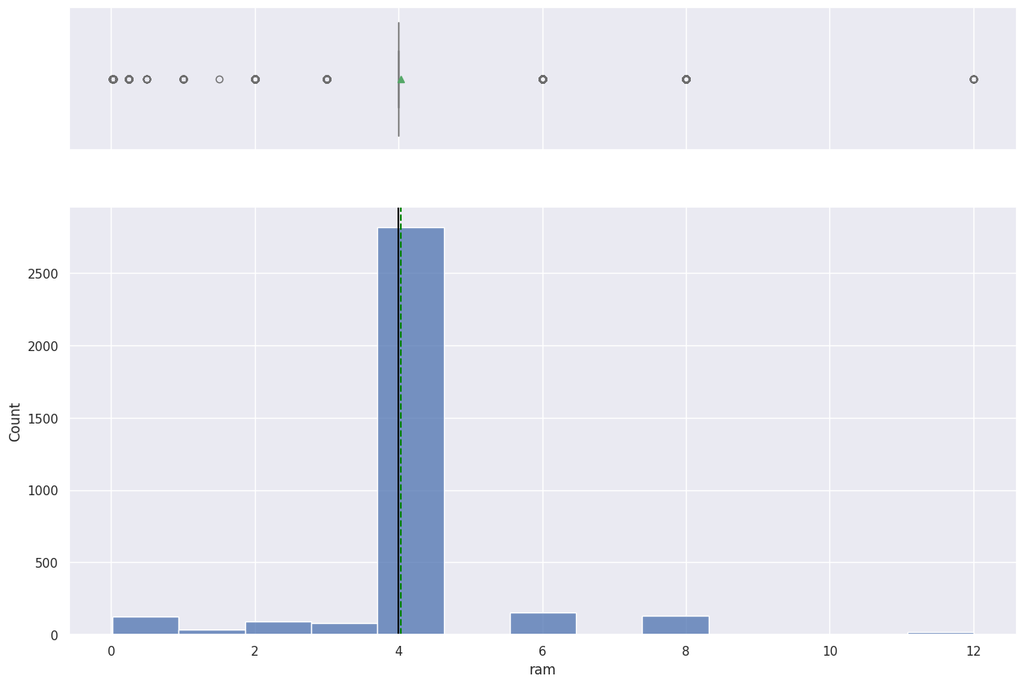

```python
# histogram and box plot for ram size
histogram_boxplot(data_eda, "ram")
```

### **Observations:**

- **Ourliers are a lot.**
- **Mode and median are almost equal - 4GB.**
- **Distribution is slightly right skewed.**

### **WEIGHT**

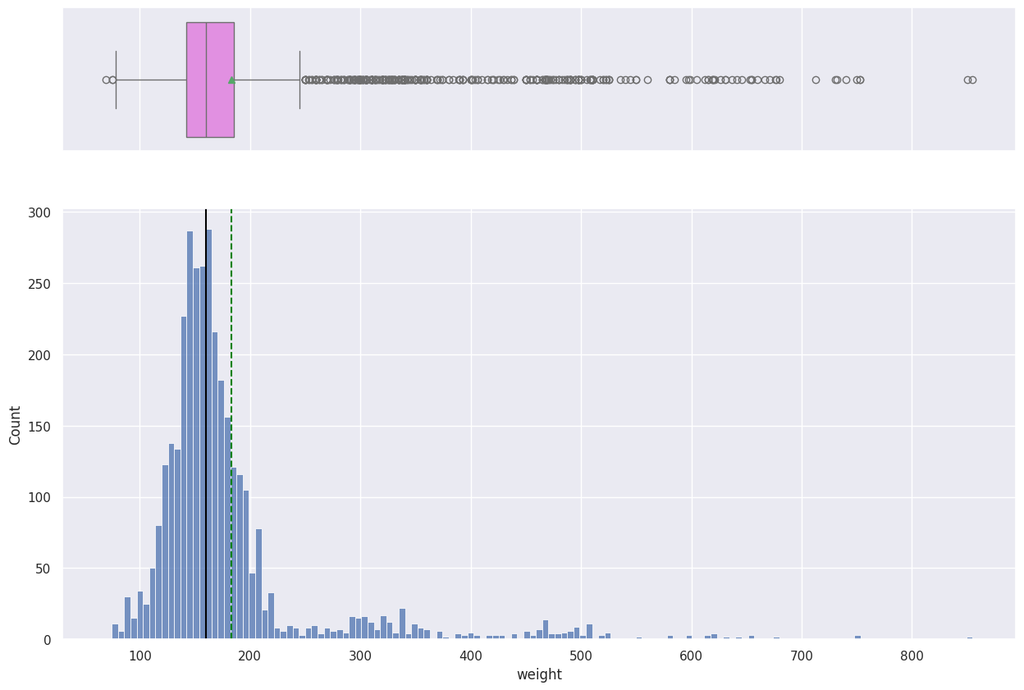

```python
# histogram and box plot for weight
histogram_boxplot(data_eda, "weight")
```

### **Observations:**

- **Distribution is right skewed.**
- **Mean is higher than the median.**
- **There are lots of outliers.**

### **BATTERY**

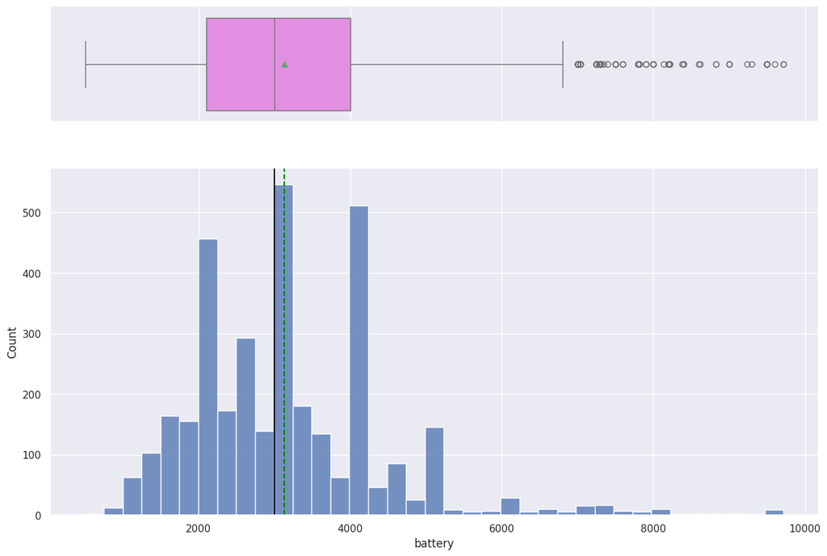

```python
# histogram and box plot for battery
histogram_boxplot(data_eda, "battery")
```

### **Observation**

- **The mean and median are around the same capacity.**
- **Distribution is slightly right skewed.**

### **DAYS USED**

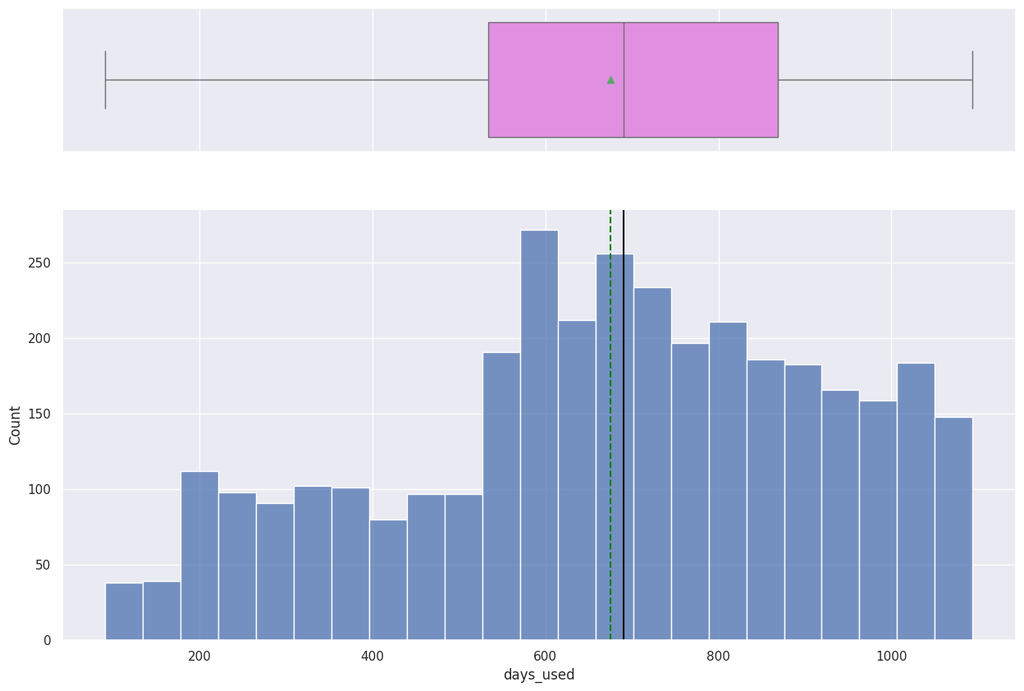

```python
# histogram and box plot for days used
histogram_boxplot(data_eda, "days_used")
```

### **Observations:**

- **Distribution is left skewed with no outliers.**
- **Median is slightly higher than the mean.**
- **All devices have been used between 100 to 1100 days.**

### **BRAND NAME**

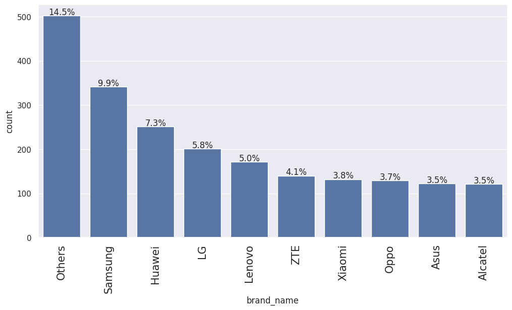

```python
# barplot for brand name
labeled_barplot(data_eda, "brand_name",perc=True, n=10)
```

### **Observations:**

- **Samsung is the brand with higher patronage.**
- **All other brands have less than 10% patronage.**

### **Question 2**

### **OPERATING SYSTEM**

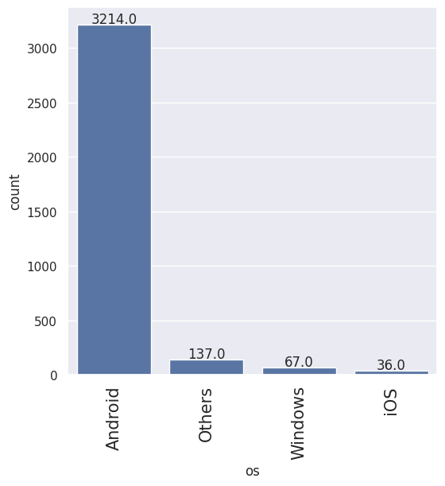

```python
# barplot for operating system
labeled_barplot(data_eda, "os")
```

```python
# percentage of operating system
data_eda["os"].value_counts(normalize=True)
```

| os | proportion |
| --- | --- |
| Android | 0.930515 |
| Others | 0.039664 |
| Windows | 0.019398 |
| iOS | 0.010423 |

**dtype:** float64

### **Observations:**

- **Android is the top most opertaing system with 93% of the total devices**
- **A total of 4 operating system are in the data.**

### **4G**

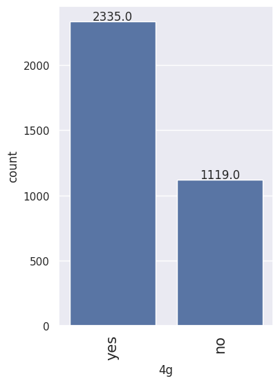

```python
# barplot for 4G
labeled_barplot(data_eda, "4g")
```

### **Observations:**

- **More than 50% of the devices support 4G.**

### **5G**

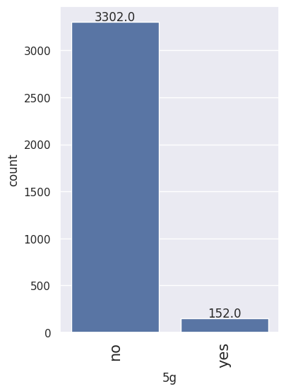

```python
# barplot for 5G
labeled_barplot(data_eda, "5g")
```

### **Observations:**

- **Less than 50% of the devices support 5G.**

### **RELEASE YEAR**

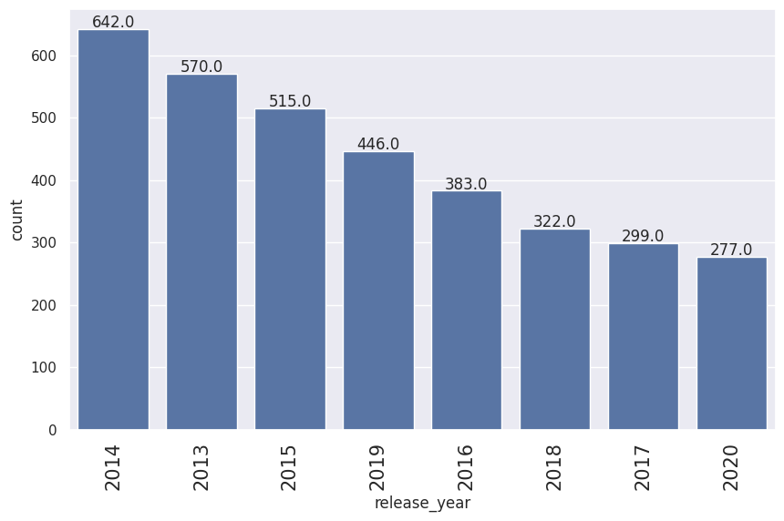

```python
# barplot for release year
labeled_barplot(data_eda, "release_year")
```

### **Observations:**

- **All devices were released from 2013 to 2020.**
- **Devices released in 2014 had the most patronage while those released in 2020 had the least patronage.**

## **BIVARIATE ANALYSIS**

### **Correlation Check.**

```python
# # Creating a list of numerical columns
num_cols = data_eda.select_dtypes(include=np.number).columns.tolist()
```

```python
#dropping release_year because it is temporal
num_cols.remove('release_year')
```

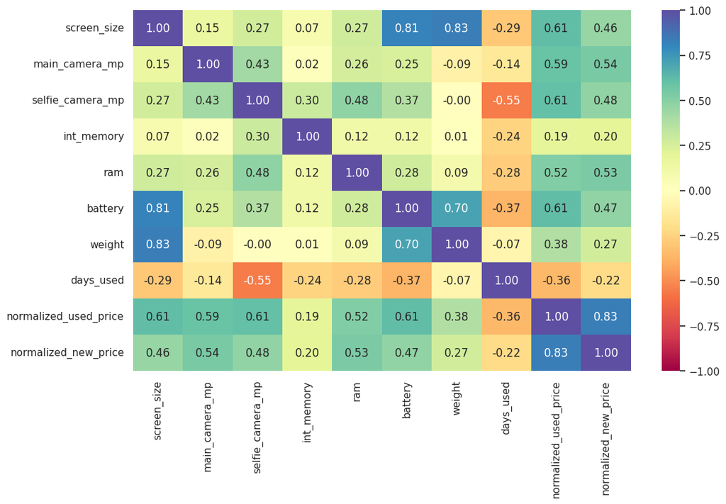

```python
plt.figure(figsize=(12, 7))
sns.heatmap(
    data_eda[num_cols].corr(), annot=True, vmin=-1, vmax=1, fmt=".2f", cmap="Spectral"
)
plt.show()
```

### **Observations:**

- **Screen size is highly correlated with battery and weight of the device - Bigger screen size means heavier device and high capacity battery.**
- **Battery and weight are also positively correlated - the higher the battery, the bigger the screen.**
- **Days used have a negative correlation with price.**
- **Used and new device price has a positive correlation**
- **Used price has correlation with most values, signifying that price depends on specs.**

### **Question 3**

## **BRAND AND RAM**

### The amount of RAM is important for the smooth functioning of a device. Checking for ram variation per brand.

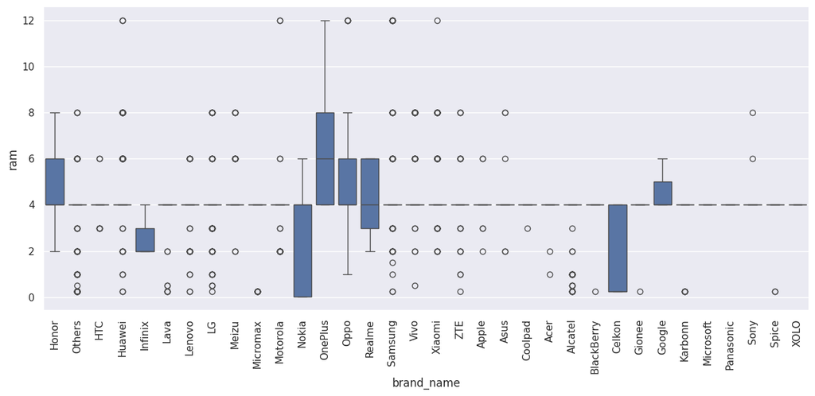

```python
# relationship between brand and ram
plt.figure(figsize=(15, 6))
sns.boxplot(data=data_eda, x="brand_name", y="ram")
plt.xticks(rotation=90)
plt.show()
```

### **Question 4**

### **WEIGHT AND BATTERY(>4500mAh)**

### Weight variation for phones and tablets offering large batteries (more than 4500 mAh).

```python
# dataframe for devices with battery more than 4500mAh
data_battery = data_eda[data_eda["battery"] > 4500]
```

```python
# shape of dataframe
data_battery.shape
```

```
(341, 15)
```

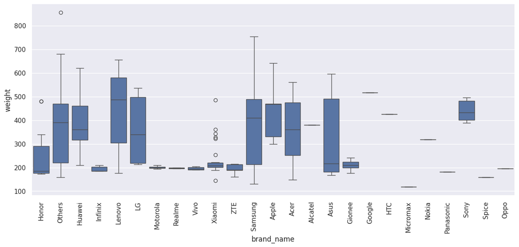

```python
# relationship between devices with battery more than 4500mAh and brand
plt.figure(figsize=(15, 6))
sns.boxplot(data=data_battery, x="brand_name", y="weight")
plt.xticks(rotation=90)
plt.show()
```

### **Question 5**

### **BRAND AND SCREEN SIZE**

### Phones and tablets are available across different brands with a screen size larger than 6 inches.

```python
# dataframe for devices with screen size larger than 6 inches ( 1 inch = 2.54 cm)
data_screen = data_eda[data_eda["screen_size"] > 6*2.54]
```

```python
# shape of dataframe
data_screen.shape
```

```
(1099, 15)
```

```python
# number of brands with screen size larger than 6 inches
data_screen["brand_name"].nunique()
```

```
31
```

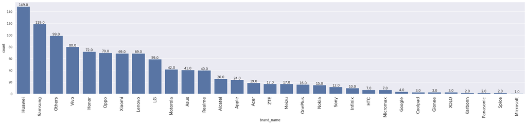

```python
# barplot for devices with screen size larger than 6 inches
labeled_barplot(data_screen, "brand_name")
```

### **Observations:**

- **There are 1099 devices with a screen size greater than 6 inches.**
- **31 brands have screen size greater than 6 inches**
- **Huawei has the greatest perentage of devices with screen sizes greater than 6 inches**
- **Microsoft has the least percentage of devices with screen sizes greater than 6 inches .**

### **Question 6**

## **BRAND AND SELFIE CAMERA**

### Devices offering greater than 8MP selfie cameras across brands.

```python
# dataframe for devices with selfie camera greater than 8 megapixels
data_selfie = data_eda[data_eda["selfie_camera_mp"] > 8]
```

```python
# dataframe shape
data_selfie.shape
```

```
(655, 15)
```

```python
# number of brands with selfie camera > 8 megapixels
data_selfie["brand_name"].nunique()
```

```
25
```

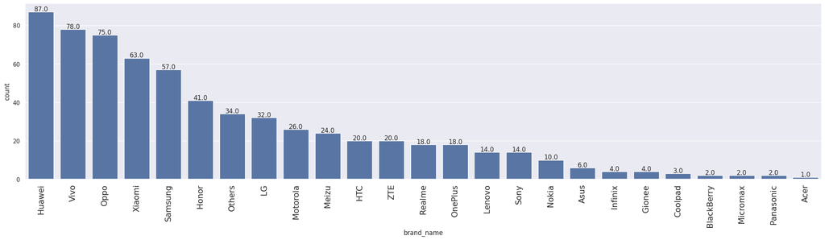

```python
# barplot for devices with selfie camera greater than 8 megapixels
labeled_barplot(data_selfie, "brand_name")
```

### **Observations:**

- **655 out of 3454 devices have selfie cameras greater than 8MP.**
- **There are 25 brands with selfie camera greater than 8MP**
- **Huawei has the greatest share of devices with selfie cameras of more than 8MP**
- **Acer has the least percentage of selfie cameras of more than 8MP.**

## **BRAND AND REAR CAMERA**

### Devices offering at least 16MP rear cameras across brands.

```python
# dataframe for devices with rear camera with at least 16 megapixels rear camera
data_rear = data_eda[data_eda["main_camera_mp"] >= 16]
```

```python
# shape of the dataframe
data_rear.shape
```

```
(248, 15)
```

```python
# number of brands with at least 16 mega pixels rear camera
data_rear["brand_name"].nunique()
```

```
26
```

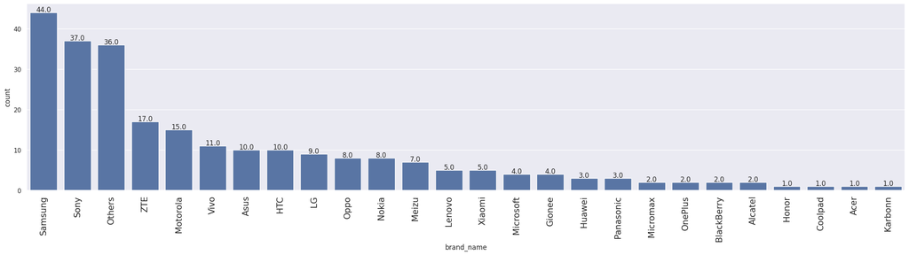

```python
 # barplot for devices with at least 16 mega pixels rear camera
labeled_barplot(data_rear, "brand_name")
```

### **Observations:**

- **248 out of 3454 devices have rear cameras with at least 16MP.**
- **There are 26 brands with rear camera with at least 16MP.**
- **Samsung has the most devices offering more than 16MP for rear camera**
- **karbonn, honor, Coolpad and Acer have just 1**

## **USED DEVICE PRICE AND RELEASE YEAR**

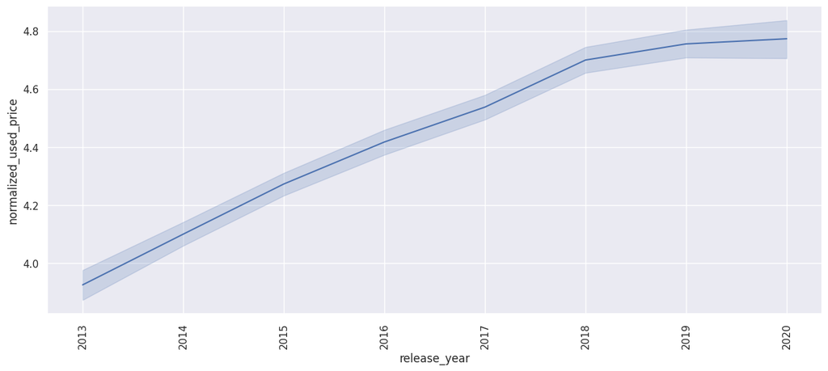

```python
 # line plot for used device price and variation with released year
plt.figure(figsize=(15, 6))
sns.lineplot(data=data_eda, x="release_year", y="normalized_used_price")
plt.xticks(rotation=90)
plt.show()
```

### **Observation**

- **Prices for used phones increases with year of release**

## **DEVICES AND NETWORK TECHNOLOGY**

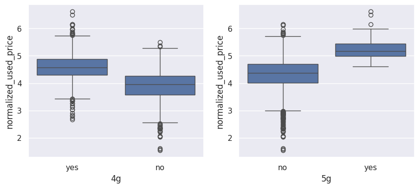

```python
# relationship between prices of used devices and 4G and 5G
plt.figure(figsize=(10, 4))

plt.subplot(121)
sns.boxplot(data=data_eda, x="4g", y="normalized_used_price")

plt.subplot(122)
sns.boxplot(data=data_eda, x="5g", y="normalized_used_price")

plt.show()
```

### **Observation:**

- **Prices for used devices that supports 5G are higher as compared to that of the 4G(median for 5G > median for 4G)**
- **prices for used devices that does not support 5G is still higher as compared to those that does not support 4G (median for non 5G > median for non 4G).**

## Data Preprocessing

- Missing value treatment
- Feature engineering (if needed)
- Outlier detection and treatment (if needed)
- Preparing data for modeling
- Any other preprocessing steps (if needed)
- Missing value treatment

```python
# copy of the data set
data_1 = data.copy()
```

```python
# checking for missing values
data_1.isnull().sum()
```

|  | 0 |
| --- | --- |
| brand_name | 0 |
| os | 0 |
| screen_size | 0 |
| 4g | 0 |
| 5g | 0 |
| main_camera_mp | 179 |
| selfie_camera_mp | 2 |
| int_memory | 4 |
| ram | 4 |
| battery | 6 |
| weight | 7 |
| release_year | 0 |
| days_used | 0 |
| normalized_used_price | 0 |
| normalized_new_price | 0 |

**dtype:** int64

```python
# Treating missing values by the columns medians grouped by realease year and brand name
data_1['selfie_camera_mp'] = data_1['selfie_camera_mp'].fillna(value=data_1.groupby(['release_year', 'brand_name'])['selfie_camera_mp'].transform('median'))
data_1['main_camera_mp'] = data_1['main_camera_mp'].fillna(value=data_1.groupby(['release_year', 'brand_name'])['main_camera_mp'].transform('median'))
data_1['int_memory'] = data_1['int_memory'].fillna(value=data_1.groupby(['release_year', 'brand_name'])['int_memory'].transform("median"))
data_1['ram'] = data_1['ram'].fillna(value=data_1.groupby(['release_year', 'brand_name'])['ram'].transform('median'))
data_1['battery'] = data_1['battery'].fillna(value=data_1.groupby(['release_year','brand_name'])['battery'].transform('median'))
data_1['weight'] = data_1['weight'].fillna(value=data_1.groupby(['release_year', 'brand_name'])['weight'].transform('median'))

data_1.isnull().sum()
```

|  | 0 |
| --- | --- |
| brand_name | 0 |
| os | 0 |
| screen_size | 0 |
| 4g | 0 |
| 5g | 0 |
| main_camera_mp | 179 |
| selfie_camera_mp | 2 |
| int_memory | 0 |
| ram | 0 |
| battery | 6 |
| weight | 7 |
| release_year | 0 |
| days_used | 0 |
| normalized_used_price | 0 |
| normalized_new_price | 0 |

**dtype:** int64

```python
# list of missing values
missing_cols = ['selfie_camera_mp', 'main_camera_mp', 'int_memory', 'ram', 'battery', 'weight']
```

```python
# treating the next missing values of the columns by brand median
for col in missing_cols:
    data_1[col] = data_1[col].fillna(value=data_1.groupby('brand_name')[col].transform('median'))
```

```python
# checking for missing values
data_1.isnull().sum()
```

|  | 0 |
| --- | --- |
| brand_name | 0 |
| os | 0 |
| screen_size | 0 |
| 4g | 0 |
| 5g | 0 |
| main_camera_mp | 10 |
| selfie_camera_mp | 0 |
| int_memory | 0 |
| ram | 0 |
| battery | 0 |
| weight | 0 |
| release_year | 0 |
| days_used | 0 |
| normalized_used_price | 0 |
| normalized_new_price | 0 |

**dtype:** int64

```python
# Treat the remaing missing values for main camera with the column median
data_1['main_camera_mp'] = data_1['main_camera_mp'].fillna(value=data_1['main_camera_mp'].median())
data_1.isnull().sum()
```

|  | 0 |
| --- | --- |
| brand_name | 0 |
| os | 0 |
| screen_size | 0 |
| 4g | 0 |
| 5g | 0 |
| main_camera_mp | 0 |
| selfie_camera_mp | 0 |
| int_memory | 0 |
| ram | 0 |
| battery | 0 |
| weight | 0 |
| release_year | 0 |
| days_used | 0 |
| normalized_used_price | 0 |
| normalized_new_price | 0 |

**dtype:** int64

- Feature engineering

```python
# create a new column for years since release from the relase year
data_1['years_since_release'] = 2021 - data_1['release_year'] # consider 2021 as baseline since data was collected in that year
```

```python
 # drop the release year column
data_1.drop('release_year', axis=1, inplace=True)
data_1['years_since_release'].describe()
```

|  | years_since_release |
| --- | --- |
| count | 3454.000000 |
| mean | 5.034742 |
| std | 2.298455 |
| min | 1.000000 |
| 25% | 3.000000 |
| 50% | 5.500000 |
| 75% | 7.000000 |
| max | 8.000000 |

**dtype:** float64

### **Observations:**

- **25% of used devices were released 3 years ago and 50% of them, 5.5 years ago.**
- Outlier detection and treatment

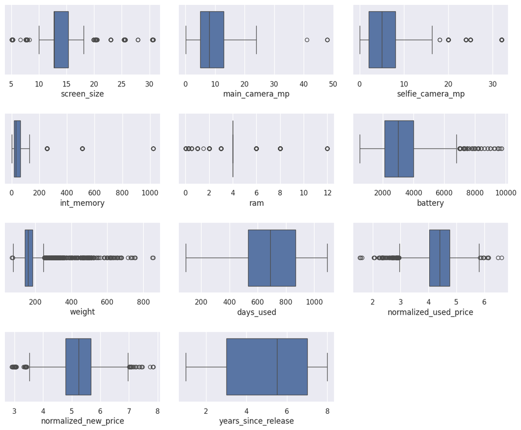

```python
# checking for outliers using box plot
num_cols = data_1.select_dtypes(include=np.number).columns.tolist()

plt.figure(figsize=(12, 10))

for i, variable in enumerate(num_cols):
    plt.subplot(4, 3, i + 1)
    sns.boxplot(data=data_1, x=variable)
    plt.tight_layout(pad=2)

plt.show()
```

### **Observations:**

- **There are outliers in the data. They will not be treated since they are proper values**

## Preparing data for modeling

- We want to predict the price for used and refurbished devices.
- Before we proceed to build a model, we'll have to encode categorical features.
- We'll split the data into train and test to be able to evaluate the model that we build on the train data.
- We'll build a Linear Regression model using the train data and then check it's performace.

```python
# let us define X (independent) and y (dependent) variables
X = data_1.drop(['normalized_used_price', 'normalized_new_price'], axis=1)
y = data_1['normalized_used_price']

print(X.head())
print(y.head())
```

```
  brand_name       os  screen_size   4g   5g  main_camera_mp  \
0      Honor  Android        14.50  yes   no            13.0
1      Honor  Android        17.30  yes  yes            13.0
2      Honor  Android        16.69  yes  yes            13.0
3      Honor  Android        25.50  yes  yes            13.0
4      Honor  Android        15.32  yes   no            13.0

   selfie_camera_mp  int_memory  ram  battery  weight  days_used  \
0               5.0        64.0  3.0   3020.0   146.0        127
1              16.0       128.0  8.0   4300.0   213.0        325
2               8.0       128.0  8.0   4200.0   213.0        162
3               8.0        64.0  6.0   7250.0   480.0        345
4               8.0        64.0  3.0   5000.0   185.0        293

   years_since_release
0                    1
1                    1
2                    1
3                    1
4                    1
0    4.307572
1    5.162097
2    5.111084
3    5.135387
4    4.389995
Name: normalized_used_price, dtype: float64
```

```python
# addition of intercept to the data
X = sm.add_constant(X)
```

```python
# Creating dummy variables
X = pd.get_dummies(X, dtype=int, columns=X.select_dtypes(include=['object', 'category']).columns.tolist(), drop_first=True)
X.head()
```

|  | const | screen_size | main_camera_mp | selfie_camera_mp | int_memory | ram | battery | weight | days_used | years_since_release | ... | brand_name_Spice | brand_name_Vivo | brand_name_XOLO | brand_name_Xiaomi | brand_name_ZTE | os_Others | os_Windows | os_iOS | 4g_yes | 5g_yes |
| --- | --- | --- | --- | --- | --- | --- | --- | --- | --- | --- | --- | --- | --- | --- | --- | --- | --- | --- | --- | --- | --- |
| 0 | 1.0 | 14.50 | 13.0 | 5.0 | 64.0 | 3.0 | 3020.0 | 146.0 | 127 | 1 | ... | 0 | 0 | 0 | 0 | 0 | 0 | 0 | 0 | 1 | 0 |
| 1 | 1.0 | 17.30 | 13.0 | 16.0 | 128.0 | 8.0 | 4300.0 | 213.0 | 325 | 1 | ... | 0 | 0 | 0 | 0 | 0 | 0 | 0 | 0 | 1 | 1 |
| 2 | 1.0 | 16.69 | 13.0 | 8.0 | 128.0 | 8.0 | 4200.0 | 213.0 | 162 | 1 | ... | 0 | 0 | 0 | 0 | 0 | 0 | 0 | 0 | 1 | 1 |
| 3 | 1.0 | 25.50 | 13.0 | 8.0 | 64.0 | 6.0 | 7250.0 | 480.0 | 345 | 1 | ... | 0 | 0 | 0 | 0 | 0 | 0 | 0 | 0 | 1 | 1 |
| 4 | 1.0 | 15.32 | 13.0 | 8.0 | 64.0 | 3.0 | 5000.0 | 185.0 | 293 | 1 | ... | 0 | 0 | 0 | 0 | 0 | 0 | 0 | 0 | 1 | 0 |

5 rows × 48 columns

```python
# Splitting the data in 70:30 ratio for train to test data
X_train, X_test, y_train, y_test = train_test_split(X, y, test_size=0.30, random_state=1)
```

```python
print(X_train.shape[0])
print(X_test.shape[0])
```

```
2417
1037
```

- **Number of rows in the train data = 2417**
- **Number of rows in the text dta = 1037**

## EDA

- It is a good idea to explore the data once again after manipulating it.

```python
# data information after manipulating it
data_1.info()
```

```
<class 'pandas.core.frame.DataFrame'>
RangeIndex: 3454 entries, 0 to 3453
Data columns (total 15 columns):
 #   Column                 Non-Null Count  Dtype
---  ------                 --------------  -----
 0   brand_name             3454 non-null   object
 1   os                     3454 non-null   object
 2   screen_size            3454 non-null   float64
 3   4g                     3454 non-null   object
 4   5g                     3454 non-null   object
 5   main_camera_mp         3454 non-null   float64
 6   selfie_camera_mp       3454 non-null   float64
 7   int_memory             3454 non-null   float64
 8   ram                    3454 non-null   float64
 9   battery                3454 non-null   float64
 10  weight                 3454 non-null   float64
 11  days_used              3454 non-null   int64
 12  normalized_used_price  3454 non-null   float64
 13  normalized_new_price   3454 non-null   float64
 14  years_since_release    3454 non-null   int64
dtypes: float64(9), int64(2), object(4)
memory usage: 404.9+ KB
```

- **values in columns are same as original**

```python
 # checking for missing values
data_1.isnull().sum()
```

|  | 0 |
| --- | --- |
| brand_name | 0 |
| os | 0 |
| screen_size | 0 |
| 4g | 0 |
| 5g | 0 |
| main_camera_mp | 0 |
| selfie_camera_mp | 0 |
| int_memory | 0 |
| ram | 0 |
| battery | 0 |
| weight | 0 |
| days_used | 0 |
| normalized_used_price | 0 |
| normalized_new_price | 0 |
| years_since_release | 0 |

**dtype:** int64

- **There are no missing values**

```python
 # statistical summary
data_1.describe()
```

|  | screen_size | main_camera_mp | selfie_camera_mp | int_memory | ram | battery | weight | days_used | normalized_used_price | normalized_new_price | years_since_release |
| --- | --- | --- | --- | --- | --- | --- | --- | --- | --- | --- | --- |
| count | 3454.000000 | 3454.000000 | 3454.000000 | 3454.000000 | 3454.000000 | 3454.000000 | 3454.000000 | 3454.000000 | 3454.000000 | 3454.000000 | 3454.000000 |
| mean | 13.713115 | 9.617597 | 6.555067 | 54.528474 | 4.032620 | 3132.577446 | 182.636856 | 674.869716 | 4.364712 | 5.233107 | 5.034742 |
| std | 3.805280 | 4.749438 | 6.968440 | 84.934991 | 1.368598 | 1298.884193 | 88.360445 | 248.580166 | 0.588914 | 0.683637 | 2.298455 |
| min | 5.080000 | 0.080000 | 0.000000 | 0.010000 | 0.020000 | 500.000000 | 69.000000 | 91.000000 | 1.536867 | 2.901422 | 1.000000 |
| 25% | 12.700000 | 5.000000 | 2.000000 | 16.000000 | 4.000000 | 2100.000000 | 142.000000 | 533.500000 | 4.033931 | 4.790342 | 3.000000 |
| 50% | 12.830000 | 8.000000 | 5.000000 | 32.000000 | 4.000000 | 3000.000000 | 160.000000 | 690.500000 | 4.405133 | 5.245892 | 5.500000 |
| 75% | 15.340000 | 13.000000 | 8.000000 | 64.000000 | 4.000000 | 4000.000000 | 185.000000 | 868.750000 | 4.755700 | 5.673718 | 7.000000 |
| max | 30.710000 | 48.000000 | 32.000000 | 1024.000000 | 12.000000 | 9720.000000 | 855.000000 | 1094.000000 | 6.619433 | 7.847841 | 8.000000 |

- **All missing values were replaced with values**

## Model Building - Linear Regression

```python
# linear model using statsmodels OLS and print the model summary
model = sm.OLS(y_train, X_train).fit()
print(model.summary())
```

```
                              OLS Regression Results
=================================================================================
Dep. Variable:     normalized_used_price   R-squared:                       0.764
Model:                               OLS   Adj. R-squared:                  0.759
Method:                    Least Squares   F-statistic:                     163.1
Date:                   Wed, 09 Oct 2024   Prob (F-statistic):               0.00
Time:                           22:55:28   Log-Likelihood:                -383.49
No. Observations:                   2417   AIC:                             863.0
Df Residuals:                       2369   BIC:                             1141.
Df Model:                             47
Covariance Type:               nonrobust
=========================================================================================
                            coef    std err          t      P>|t|      [0.025      0.975]
-----------------------------------------------------------------------------------------
const                     2.5968      0.076     34.367      0.000       2.449       2.745
screen_size               0.0383      0.004      9.168      0.000       0.030       0.046
main_camera_mp            0.0405      0.002     23.545      0.000       0.037       0.044
selfie_camera_mp          0.0208      0.001     15.264      0.000       0.018       0.023
int_memory                0.0007   8.35e-05      8.487      0.000       0.001       0.001
ram                       0.0660      0.006     10.684      0.000       0.054       0.078
battery                4.229e-07   8.95e-06      0.047      0.962   -1.71e-05     1.8e-05
weight                    0.0011      0.000      6.972      0.000       0.001       0.001
days_used               1.33e-05    3.8e-05      0.350      0.727   -6.13e-05    8.79e-05
years_since_release       0.0176      0.005      3.245      0.001       0.007       0.028
brand_name_Alcatel       -0.0229      0.059     -0.391      0.696      -0.138       0.092
brand_name_Apple          0.3780      0.181      2.090      0.037       0.023       0.733
brand_name_Asus           0.0544      0.059      0.921      0.357      -0.061       0.170
brand_name_BlackBerry     0.1029      0.086      1.190      0.234      -0.067       0.272
brand_name_Celkon        -0.2536      0.081     -3.116      0.002      -0.413      -0.094
brand_name_Coolpad       -0.0647      0.090     -0.720      0.472      -0.241       0.111
brand_name_Gionee         0.1050      0.071      1.475      0.140      -0.035       0.245
brand_name_Google         0.2432      0.104      2.341      0.019       0.039       0.447
brand_name_HTC            0.0700      0.059      1.179      0.238      -0.046       0.186
brand_name_Honor         -0.0342      0.061     -0.565      0.572      -0.153       0.085
brand_name_Huawei         0.0134      0.055      0.244      0.807      -0.094       0.121
brand_name_Infinix        0.0240      0.115      0.209      0.834      -0.201       0.249
brand_name_Karbonn       -0.0462      0.083     -0.559      0.576      -0.208       0.116
brand_name_LG             0.0580      0.056      1.039      0.299      -0.051       0.167
brand_name_Lava          -0.0684      0.077     -0.891      0.373      -0.219       0.082
brand_name_Lenovo        -0.0039      0.056     -0.070      0.944      -0.113       0.105
```

[output cut: 18 more lines]

```
os_Windows               -0.0265      0.056     -0.475      0.635      -0.136       0.083
os_iOS                   -0.0742      0.181     -0.410      0.681      -0.428       0.280
4g_yes                    0.1550      0.019      8.060      0.000       0.117       0.193
5g_yes                    0.0620      0.039      1.607      0.108      -0.014       0.138
==============================================================================
Omnibus:                      171.229   Durbin-Watson:                   1.970
Prob(Omnibus):                  0.000   Jarque-Bera (JB):              778.219
Skew:                          -0.153   Prob(JB):                    1.03e-169
Kurtosis:                       5.763   Cond. No.                     1.78e+05
==============================================================================

Notes:
[1] Standard Errors assume that the covariance matrix of the errors is correctly specified.
[2] The condition number is large, 1.78e+05. This might indicate that there are
strong multicollinearity or other numerical problems.
```

### Interpreting the Regression Results:

- **R-squared and adjusted R-square have values of 0.764 and 0.759 respectively. The difference in values is an indication of insignificant columns in the data. However, their values are good signifying a better fit.**
- **Dependent variable is normalised used price.**
- **some insignificant columns are 5G operating system and days used. Brands such as blackberry, Huawei, lenove and HTC are insignifant in terms of normalised used price.**
- **Apple and Google brands have a strong positive effect on mormalised used price but Alcatel, Celkon,Coolpad and Sony affects normalised price negatively.**

## Model Performance Check

**Let's check the performance of the model using different metrics.**

- We will be using metric functions defined in sklearn for RMSE, MAE, and $R^2$.
- We will define a function to calculate MAPE and adjusted $R^2$.
- We will create a function which will print out all the above metrics in one go.

```python
# function to compute adjusted R-squared
def adj_r2_score(predictors, targets, predictions):
    r2 = r2_score(targets, predictions)
    n = predictors.shape[0]
    k = predictors.shape[1]
    return 1 - ((1 - r2) * (n - 1) / (n - k - 1))


# function to compute MAPE
def mape_score(targets, predictions):
    return np.mean(np.abs(targets - predictions) / targets) * 100


# function to compute different metrics to check performance of a regression model
def model_performance_regression(model, predictors, target):
    """
    Function to compute different metrics to check regression model performance

    model: regressor
    predictors: independent variables
    target: dependent variable
    """

    # predicting using the independent variables
    pred = model.predict(predictors)

    r2 = r2_score(target, pred)  # to compute R-squared
    adjr2 = adj_r2_score(predictors, target, pred)  # to compute adjusted R-squared
    rmse = np.sqrt(mean_squared_error(target, pred))  # to compute RMSE
    mae = mean_absolute_error(target, pred)  # to compute MAE
    mape = mape_score(target, pred)  # to compute MAPE

    # creating a dataframe of metrics
    df_perf = pd.DataFrame(
        {
            "RMSE": rmse,
            "MAE": mae,
            "R-squared": r2,
            "Adj. R-squared": adjr2,
            "MAPE": mape,
        },
        index=[0],
    )

    return df_perf
```

```python
# checking model performance on train set (seen 70% data)
print("Training Performance\n")
model_performance_regression(model, X_train, y_train)
```

```
Training Performance
```

|  | RMSE | MAE | R-squared | Adj. R-squared | MAPE |
| --- | --- | --- | --- | --- | --- |
| 0 | 0.283576 | 0.210514 | 0.763966 | 0.759182 | 5.059632 |

```python
# checking model performance on test set (seen 30% data)
print("Test Performance\n")
model_performance_regression(model, X_test, y_test)
```

```
Test Performance
```

|  | RMSE | MAE | R-squared | Adj. R-squared | MAPE |
| --- | --- | --- | --- | --- | --- |
| 0 | 0.292598 | 0.216768 | 0.762632 | 0.7511 | 5.319517 |

**Observations**

- **The training $R^2$ is 0.76, so the model is not underfitting.**
- **Train and test RMSE and MAE are similar, so the model is not overfitting.**
- **MAE suggests that the model can predict normalised used price within a mean error of 0.22 on the test data.**
- **MAPE of 5.3 on the test data means that we are able to predict within 5.3% of the normalised used price.**

## Checking Linear Regression Assumptions

- In order to make statistical inferences from a linear regression model, it is important to ensure that the assumptions of linear regression are satisfied.

In order to satisfy the assumptions of linear regression, we have to check the following:

1. **No Multicollinearity**
2. **Linearity of variables**
3. **Independence of error terms**
4. **Normality of error terms**
5. **No Heteroscedasticity**

## MULTICOLLINEARITY TEST

We will test for multicollinearity using VIF.

- If VIF is 1 then there is no correlation between kth predictor and the remaining predictor variables.
- If VIF exceeds 5 or is close to exceeding 5, we say there is moderate multicollinearity.
- If VIF is 10 or exceeding 10, it shows signs of high multicollinearity.

```python
# Defining a function to check VIF
def checking_vif(predictors):
    vif = pd.DataFrame()
    vif["feature"] = predictors.columns

    # calculating VIF for each feature
    vif["VIF"] = [
        variance_inflation_factor(predictors.values, i)
        for i in range(len(predictors.columns))
    ]
    return vif
```

```python
# Checking the VIF of the predictors
checking_vif(X_train)
```

|  | feature | VIF |
| --- | --- | --- |
| 0 | const | 168.204163 |
| 1 | screen_size | 7.574465 |
| 2 | main_camera_mp | 1.967682 |
| 3 | selfie_camera_mp | 2.716212 |
| 4 | int_memory | 1.284271 |
| 5 | ram | 2.153585 |
| 6 | battery | 4.063070 |
| 7 | weight | 6.390324 |
| 8 | days_used | 2.658386 |
| 9 | years_since_release | 4.573531 |
| 10 | brand_name_Alcatel | 3.403907 |
| 11 | brand_name_Apple | 12.986454 |
| 12 | brand_name_Asus | 3.330220 |
| 13 | brand_name_BlackBerry | 1.627640 |
| 14 | brand_name_Celkon | 1.760727 |
| 15 | brand_name_Coolpad | 1.466368 |
| 16 | brand_name_Gionee | 1.949553 |
| 17 | brand_name_Google | 1.310409 |
| 18 | brand_name_HTC | 3.402164 |
| 19 | brand_name_Honor | 3.335832 |
| 20 | brand_name_Huawei | 5.983270 |
| 21 | brand_name_Infinix | 1.281633 |
| 22 | brand_name_Karbonn | 1.568123 |
| 23 | brand_name_LG | 4.840146 |
| 24 | brand_name_Lava | 1.707676 |
| 25 | brand_name_Lenovo | 4.554551 |
| 26 | brand_name_Meizu | 2.179070 |
| 27 | brand_name_Micromax | 3.339824 |
| 28 | brand_name_Microsoft | 1.869275 |
| 29 | brand_name_Motorola | 3.267530 |
| 30 | brand_name_Nokia | 3.471182 |
| 31 | brand_name_OnePlus | 1.434886 |
| 32 | brand_name_Oppo | 3.968848 |
| 33 | brand_name_Others | 9.711025 |
| 34 | brand_name_Panasonic | 2.101595 |
| 35 | brand_name_Realme | 1.936636 |
| 36 | brand_name_Samsung | 7.509092 |
| 37 | brand_name_Sony | 2.942164 |
| 38 | brand_name_Spice | 1.680508 |
| 39 | brand_name_Vivo | 3.651209 |
| 40 | brand_name_XOLO | 2.135965 |
| 41 | brand_name_Xiaomi | 3.711835 |
| 42 | brand_name_ZTE | 3.794226 |
| 43 | os_Others | 1.830096 |
| 44 | os_Windows | 1.596013 |
| 45 | os_iOS | 11.784657 |
| 46 | 4g_yes | 2.384673 |
| 47 | 5g_yes | 1.787560 |

### **observations:**

- **There are somecolumns with high VIF values.**
- **We will drop numerical columns with VIF > 5 one by one.**
- **We ignore the VIF values for dummy variables and the intercept.**

## Removing multicollinearity

```python
# Creating a function to check the effect of dropping high VIF columns
def treating_multicollinearity(predictors, target, high_vif_columns):
    """
    Checking the effect of dropping the columns showing high multicollinearity
    on model performance (adj. R-squared and RMSE)

    predictors: independent variables
    target: dependent variable
    high_vif_columns: columns having high VIF
    """
    # empty lists to store adj. R-squared and RMSE values
    adj_r2 = []
    rmse = []

    # build ols models by dropping one of the high VIF columns at a time
    # store the adjusted R-squared and RMSE in the lists defined previously
    for cols in high_vif_columns:
        # defining the new train set
        train = predictors.loc[:, ~predictors.columns.str.startswith(cols)]

        # create the model
        olsmodel = sm.OLS(target, train).fit()

        # adding adj. R-squared and RMSE to the lists
        adj_r2.append(olsmodel.rsquared_adj)
        rmse.append(np.sqrt(olsmodel.mse_resid))

    # creating a dataframe for the results
    temp = pd.DataFrame(
        {
            "col": high_vif_columns,
            "Adj. R-squared after_dropping col": adj_r2,
            "RMSE after dropping col": rmse,
        }
    ).sort_values(by="Adj. R-squared after_dropping col", ascending=False)
    temp.reset_index(drop=True, inplace=True)

    return temp
```

```python
# Observing the effect of dropping the column 'screen_size'
col_list = ['screen_size', 'weight']

res = treating_multicollinearity(X_train, y_train, col_list)
res
```

|  | col | Adj. R-squared after_dropping col | RMSE after dropping col |
| --- | --- | --- | --- |
| 0 | weight | 0.754448 | 0.289297 |
| 1 | screen_size | 0.750849 | 0.291410 |

```python
# dropping  it has a higher VIF value
col_to_drop = 'screen_size'
X_train2 = X_train.loc[:, ~X_train.columns.str.startswith(col_to_drop)]
X_test2 = X_test.loc[:, ~X_test.columns.str.startswith(col_to_drop)]

# Check VIF now
vif = checking_vif(X_train2)
print("VIF after dropping ", col_to_drop)
vif
```

```
VIF after dropping  screen_size
```

|  | feature | VIF |
| --- | --- | --- |
| 0 | const | 132.921470 |
| 1 | main_camera_mp | 1.952620 |
| 2 | selfie_camera_mp | 2.707110 |
| 3 | int_memory | 1.284094 |
| 4 | ram | 2.151972 |
| 5 | battery | 3.805103 |
| 6 | weight | 2.906460 |
| 7 | days_used | 2.645782 |
| 8 | years_since_release | 4.453102 |
| 9 | brand_name_Alcatel | 3.403846 |
| 10 | brand_name_Apple | 12.912388 |
| 11 | brand_name_Asus | 3.325514 |
| 12 | brand_name_BlackBerry | 1.626812 |
| 13 | brand_name_Celkon | 1.759957 |
| 14 | brand_name_Coolpad | 1.465893 |
| 15 | brand_name_Gionee | 1.940526 |
| 16 | brand_name_Google | 1.309014 |
| 17 | brand_name_HTC | 3.393695 |
| 18 | brand_name_Honor | 3.335727 |
| 19 | brand_name_Huawei | 5.980718 |
| 20 | brand_name_Infinix | 1.280933 |
| 21 | brand_name_Karbonn | 1.568090 |
| 22 | brand_name_LG | 4.825531 |
| 23 | brand_name_Lava | 1.707121 |
| 24 | brand_name_Lenovo | 4.548154 |
| 25 | brand_name_Meizu | 2.175530 |
| 26 | brand_name_Micromax | 3.332019 |
| 27 | brand_name_Microsoft | 1.867541 |
| 28 | brand_name_Motorola | 3.252895 |
| 29 | brand_name_Nokia | 3.458346 |
| 30 | brand_name_OnePlus | 1.434886 |
| 31 | brand_name_Oppo | 3.963851 |
| 32 | brand_name_Others | 9.651934 |
| 33 | brand_name_Panasonic | 2.100239 |
| 34 | brand_name_Realme | 1.932203 |
| 35 | brand_name_Samsung | 7.497284 |
| 36 | brand_name_Sony | 2.936849 |
| 37 | brand_name_Spice | 1.673159 |
| 38 | brand_name_Vivo | 3.650484 |
| 39 | brand_name_XOLO | 2.135545 |
| 40 | brand_name_Xiaomi | 3.704380 |
| 41 | brand_name_ZTE | 3.784193 |
| 42 | os_Others | 1.572249 |
| 43 | os_Windows | 1.595924 |
| 44 | os_iOS | 11.677097 |
| 45 | 4g_yes | 2.384640 |
| 46 | 5g_yes | 1.785829 |

### **Observations:**

- **All numerical columns with higher VIF values have been dropped.**

### Dropping high p-value variables

- P-value greater than 0.05 will be dropped as they do not significantly impact the target variable
- We will drop variables one by one since p-values can change after dropping a variable.
- We will start by dropping the column with the highest p-value.

```python
#  model building using the updated set of predictors variables.
model2 = sm.OLS(y_train, X_train2).fit()
print(model2.summary())
```

```
                              OLS Regression Results
=================================================================================
Dep. Variable:     normalized_used_price   R-squared:                       0.756
Model:                               OLS   Adj. R-squared:                  0.751
Method:                    Least Squares   F-statistic:                     159.3
Date:                   Thu, 10 Oct 2024   Prob (F-statistic):               0.00
Time:                           00:03:54   Log-Likelihood:                -425.62
No. Observations:                   2417   AIC:                             945.2
Df Residuals:                       2370   BIC:                             1217.
Df Model:                             46
Covariance Type:               nonrobust
=========================================================================================
                            coef    std err          t      P>|t|      [0.025      0.975]
-----------------------------------------------------------------------------------------
const                     2.9141      0.068     42.642      0.000       2.780       3.048
main_camera_mp            0.0419      0.002     24.024      0.000       0.038       0.045
selfie_camera_mp          0.0215      0.001     15.551      0.000       0.019       0.024
int_memory                0.0007   8.49e-05      8.237      0.000       0.001       0.001
ram                       0.0675      0.006     10.752      0.000       0.055       0.080
battery                 2.11e-05   8.81e-06      2.394      0.017    3.82e-06    3.84e-05
weight                    0.0023      0.000     20.027      0.000       0.002       0.002
days_used             -1.072e-05   3.86e-05     -0.278      0.781   -8.64e-05     6.5e-05
years_since_release       0.0095      0.005      1.750      0.080      -0.001       0.020
brand_name_Alcatel       -0.0207      0.060     -0.346      0.729      -0.138       0.096
brand_name_Apple          0.5033      0.184      2.742      0.006       0.143       0.863
brand_name_Asus           0.0340      0.060      0.567      0.571      -0.084       0.152
brand_name_BlackBerry     0.0850      0.088      0.967      0.334      -0.087       0.257
brand_name_Celkon        -0.2692      0.083     -3.252      0.001      -0.432      -0.107
brand_name_Coolpad       -0.0795      0.091     -0.870      0.384      -0.259       0.100
brand_name_Gionee         0.0606      0.072      0.839      0.402      -0.081       0.202
brand_name_Google         0.2121      0.106      2.008      0.045       0.005       0.419
brand_name_HTC            0.0428      0.060      0.710      0.478      -0.075       0.161
brand_name_Honor         -0.0311      0.062     -0.505      0.614      -0.152       0.090
brand_name_Huawei         0.0030      0.056      0.054      0.957      -0.106       0.112
brand_name_Infinix       -0.0006      0.117     -0.005      0.996      -0.230       0.228
brand_name_Karbonn       -0.0426      0.084     -0.507      0.612      -0.207       0.122
brand_name_LG             0.0299      0.057      0.527      0.598      -0.081       0.141
brand_name_Lava          -0.0811      0.078     -1.039      0.299      -0.234       0.072
brand_name_Lenovo        -0.0231      0.057     -0.407      0.684      -0.134       0.088
brand_name_Meizu         -0.0693      0.070     -0.987      0.324      -0.207       0.068
```

[output cut: 17 more lines]

```
os_Windows               -0.0227      0.057     -0.400      0.689      -0.134       0.088
os_iOS                   -0.2324      0.183     -1.270      0.204      -0.591       0.126
4g_yes                    0.1557      0.020      7.956      0.000       0.117       0.194
5g_yes                    0.0510      0.039      1.300      0.194      -0.026       0.128
==============================================================================
Omnibus:                      171.193   Durbin-Watson:                   1.955
Prob(Omnibus):                  0.000   Jarque-Bera (JB):              707.348
Skew:                          -0.213   Prob(JB):                    2.52e-154
Kurtosis:                       5.616   Cond. No.                     1.78e+05
==============================================================================

Notes:
[1] Standard Errors assume that the covariance matrix of the errors is correctly specified.
[2] The condition number is large, 1.78e+05. This might indicate that there are
strong multicollinearity or other numerical problems.
```

### **Observation:**

- **There are few higher p values that needs to be dropped**

```python
# Initial list of columns
predictors = X_train2.copy()
cols = predictors.columns.tolist()

# Setting an initial max p-value
max_p_value = 1

while len(cols) > 0:
    # Defining the train set. Creating an auxiliary dataset
    X_train_aux = predictors[cols]

    # Fitting the model
    model = sm.OLS(y_train, X_train_aux).fit()

    # Getting the p-values and the maximum p-value
    p_values = model.pvalues
    max_p_value = max(p_values)

    # Name of the variable with maximum p-value
    feature_with_p_max = p_values.idxmax()

    if max_p_value > 0.05:
        cols.remove(feature_with_p_max)
    else:
        break

selected_features = cols
print(selected_features)
```

[output not shown]

```python
X_train3 = X_train2[selected_features]
X_test3 = X_test2[selected_features]
```

```python
# new models without high p values
model3 = sm.OLS(y_train, X_train3).fit()
print(model3.summary())
```

```
                              OLS Regression Results
=================================================================================
Dep. Variable:     normalized_used_price   R-squared:                       0.753
Model:                               OLS   Adj. R-squared:                  0.751
Method:                    Least Squares   F-statistic:                     347.7
Date:                   Thu, 10 Oct 2024   Prob (F-statistic):               0.00
Time:                           00:08:58   Log-Likelihood:                -438.36
No. Observations:                   2417   AIC:                             920.7
Df Residuals:                       2395   BIC:                             1048.
Df Model:                             21
Covariance Type:               nonrobust
=======================================================================================
                          coef    std err          t      P>|t|      [0.025      0.975]
---------------------------------------------------------------------------------------
const                   2.9168      0.028    102.612      0.000       2.861       2.973
main_camera_mp          0.0417      0.002     25.020      0.000       0.038       0.045
selfie_camera_mp        0.0205      0.001     16.973      0.000       0.018       0.023
int_memory              0.0007   8.28e-05      8.386      0.000       0.001       0.001
ram                     0.0735      0.005     13.882      0.000       0.063       0.084
battery              2.125e-05   8.18e-06      2.599      0.009    5.22e-06    3.73e-05
weight                  0.0023      0.000     20.964      0.000       0.002       0.003
brand_name_Apple        0.3056      0.053      5.790      0.000       0.202       0.409
brand_name_Celkon      -0.2269      0.066     -3.436      0.001      -0.356      -0.097
brand_name_Google       0.2237      0.093      2.416      0.016       0.042       0.405
brand_name_HTC          0.0752      0.033      2.259      0.024       0.010       0.140
brand_name_LG           0.0573      0.027      2.160      0.031       0.005       0.109
brand_name_Micromax    -0.1728      0.034     -5.100      0.000      -0.239      -0.106
brand_name_Motorola    -0.1084      0.035     -3.087      0.002      -0.177      -0.040
brand_name_Nokia        0.1406      0.039      3.648      0.000       0.065       0.216
brand_name_OnePlus      0.2052      0.082      2.499      0.013       0.044       0.366
brand_name_Oppo         0.0637      0.031      2.027      0.043       0.002       0.125
brand_name_Realme      -0.1435      0.056     -2.555      0.011      -0.254      -0.033
brand_name_Samsung      0.0723      0.020      3.540      0.000       0.032       0.112
brand_name_Spice       -0.1804      0.062     -2.909      0.004      -0.302      -0.059
os_Others              -0.3051      0.035     -8.726      0.000      -0.374      -0.237
4g_yes                  0.1436      0.017      8.216      0.000       0.109       0.178
==============================================================================
Omnibus:                      175.785   Durbin-Watson:                   1.949
Prob(Omnibus):                  0.000   Jarque-Bera (JB):              753.661
Skew:                          -0.210   Prob(JB):                    2.21e-164
Kurtosis:                       5.703   Cond. No.                     5.33e+04
==============================================================================

Notes:
[1] Standard Errors assume that the covariance matrix of the errors is correctly specified.
[2] The condition number is large, 5.33e+04. This might indicate that there are
strong multicollinearity or other numerical problems.
```

```python
# Checking model performance on train set (seen 70% data)
print("Training Performance\n")
model_performance_regression(model3, X_train3, y_train)
```

```
Training Performance
```

|  | RMSE | MAE | R-squared | Adj. R-squared | MAPE |
| --- | --- | --- | --- | --- | --- |
| 0 | 0.290087 | 0.216143 | 0.753003 | 0.750734 | 5.206485 |

```python
# Checking model performance on test set (seen 30% data)
print("Test Performance\n")
model_performance_regression(model3, X_test3, y_test)
```

```
Test Performance
```

|  | RMSE | MAE | R-squared | Adj. R-squared | MAPE |
| --- | --- | --- | --- | --- | --- |
| 0 | 0.304253 | 0.225585 | 0.743346 | 0.737778 | 5.538168 |

### **Observations:**

- **P-values are all lower than 0.05.**
- **Dropping high p-values has not significantly affected the model performance. This shows that these variables don't significantly impact the target variable.**
- **The model is able to explain almost 75% of the variance.**
- **RMSE and MAE are comparable for train and test sets indicating that the model is not overfitting.**

### TEST FOR LINEARITY AND INDEPENDENCE

### Conditions for linearity and independence

- **No patterns when fitted values and residuals are plotted**

```python
# Creating a dataframe with actual, fitted and residual values
df_pred = pd.DataFrame()

df_pred["Actual Values"] = y_train  # actual values
df_pred["Fitted Values"] = model3.fittedvalues  # predicted values
df_pred["Residuals"] = model3.resid  # residuals

df_pred.head()
```

|  | Actual Values | Fitted Values | Residuals |
| --- | --- | --- | --- |
| 3026 | 4.087488 | 3.874163 | 0.213325 |
| 1525 | 4.448399 | 4.621911 | -0.173511 |
| 1128 | 4.315353 | 4.302244 | 0.013109 |
| 3003 | 4.282068 | 4.157830 | 0.124238 |
| 2907 | 4.456438 | 4.663623 | -0.207185 |

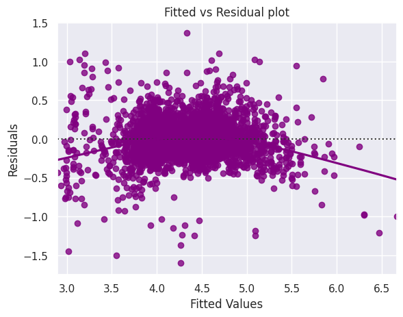

```python
# Plotting the fitted values vs residuals

sns.residplot(
    data=df_pred, x="Fitted Values", y="Residuals", color="purple", lowess=True
)
plt.xlabel("Fitted Values")
plt.ylabel("Residuals")
plt.title("Fitted vs Residual plot")
plt.show()
```

### Conditons for normality

- **Residuals should make a straight line**
- **P value should be greater than 0.05**

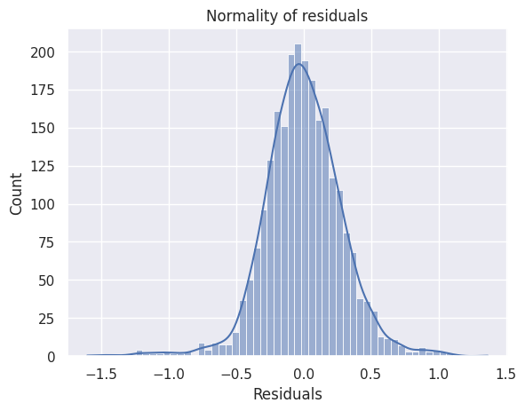

```python
# histogram for predicted values
sns.histplot(data=df_pred, x="Residuals", kde=True)
plt.title("Normality of residuals")
plt.show()
```

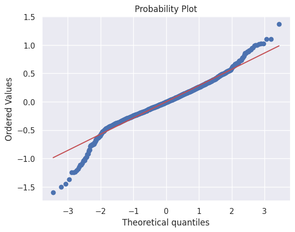

```python
# Q-Q plot
import pylab
import scipy.stats as stats

stats.probplot(df_pred["Residuals"], dist="norm", plot=pylab)
plt.show()
```

### **Observation:**

- **Most of the residuals follow a straight line.**

```python
# Shapiro Wilk test
from scipy.stats import shapiro
shapiro(df_pred["Residuals"])
```

```
ShapiroResult(statistic=0.9706367772886133, pvalue=7.591440062841769e-22)
```

### **Observations:**

- **Since the p-value is less than 0.05, the residuals are not normally distributed.**

### TEST FOR HOMOSCEDASTICITY

### We can say residuals are homoscedasticity if the p value is greater than 0.05 when we use the goldfeldquandt test

```python
# Importing the necessary libraries
import statsmodels.stats.api as sms
from statsmodels.compat import lzip

name = ["F statistic", "p-value"]
test = sms.het_goldfeldquandt(df_pred["Residuals"], X_train3)
lzip(name, test)
```

```
[('F statistic', 1.0257558277901653), ('p-value', 0.3307358877482898)]
```

### **Observation:**

- **Since p value is greater than 0.05, the residuals are homoscedastic.**

## Final Model

```python
# Recreating the final model
X_train_final = X_train3.copy()
X_test_final = X_test3.copy()
```

```python
# Print the final model summary
olsmod_final = sm.OLS(y_train, X_train_final).fit()
print(olsmod_final.summary())
```

```
                              OLS Regression Results
=================================================================================
Dep. Variable:     normalized_used_price   R-squared:                       0.753
Model:                               OLS   Adj. R-squared:                  0.751
Method:                    Least Squares   F-statistic:                     347.7
Date:                   Thu, 10 Oct 2024   Prob (F-statistic):               0.00
Time:                           01:04:07   Log-Likelihood:                -438.36
No. Observations:                   2417   AIC:                             920.7
Df Residuals:                       2395   BIC:                             1048.
Df Model:                             21
Covariance Type:               nonrobust
=======================================================================================
                          coef    std err          t      P>|t|      [0.025      0.975]
---------------------------------------------------------------------------------------
const                   2.9168      0.028    102.612      0.000       2.861       2.973
main_camera_mp          0.0417      0.002     25.020      0.000       0.038       0.045
selfie_camera_mp        0.0205      0.001     16.973      0.000       0.018       0.023
int_memory              0.0007   8.28e-05      8.386      0.000       0.001       0.001
ram                     0.0735      0.005     13.882      0.000       0.063       0.084
battery              2.125e-05   8.18e-06      2.599      0.009    5.22e-06    3.73e-05
weight                  0.0023      0.000     20.964      0.000       0.002       0.003
brand_name_Apple        0.3056      0.053      5.790      0.000       0.202       0.409
brand_name_Celkon      -0.2269      0.066     -3.436      0.001      -0.356      -0.097
brand_name_Google       0.2237      0.093      2.416      0.016       0.042       0.405
brand_name_HTC          0.0752      0.033      2.259      0.024       0.010       0.140
brand_name_LG           0.0573      0.027      2.160      0.031       0.005       0.109
brand_name_Micromax    -0.1728      0.034     -5.100      0.000      -0.239      -0.106
brand_name_Motorola    -0.1084      0.035     -3.087      0.002      -0.177      -0.040
brand_name_Nokia        0.1406      0.039      3.648      0.000       0.065       0.216
brand_name_OnePlus      0.2052      0.082      2.499      0.013       0.044       0.366
brand_name_Oppo         0.0637      0.031      2.027      0.043       0.002       0.125
brand_name_Realme      -0.1435      0.056     -2.555      0.011      -0.254      -0.033
brand_name_Samsung      0.0723      0.020      3.540      0.000       0.032       0.112
brand_name_Spice       -0.1804      0.062     -2.909      0.004      -0.302      -0.059
os_Others              -0.3051      0.035     -8.726      0.000      -0.374      -0.237
4g_yes                  0.1436      0.017      8.216      0.000       0.109       0.178
==============================================================================
Omnibus:                      175.785   Durbin-Watson:                   1.949
Prob(Omnibus):                  0.000   Jarque-Bera (JB):              753.661
Skew:                          -0.210   Prob(JB):                    2.21e-164
Kurtosis:                       5.703   Cond. No.                     5.33e+04
==============================================================================

Notes:
[1] Standard Errors assume that the covariance matrix of the errors is correctly specified.
[2] The condition number is large, 5.33e+04. This might indicate that there are
strong multicollinearity or other numerical problems.
```

```python
# Checking model performance on train set (seen 70% data)
print("Training Performance\n")
model_performance_regression(olsmod_final, X_train_final, y_train)
```

```
Training Performance
```

|  | RMSE | MAE | R-squared | Adj. R-squared | MAPE |
| --- | --- | --- | --- | --- | --- |
| 0 | 0.290087 | 0.216143 | 0.753003 | 0.750734 | 5.206485 |

```python
# Checking model performance on test set (seen 30% data)
print("Test Performance\n")
model_performance_regression(olsmod_final, X_test_final, y_test)
```

```
Test Performance
```

|  | RMSE | MAE | R-squared | Adj. R-squared | MAPE |
| --- | --- | --- | --- | --- | --- |
| 0 | 0.304253 | 0.225585 | 0.743346 | 0.737778 | 5.538168 |

## Actionable Insights and Recommendations

## The model is able to explain about 75% of the variation in the data and within 5.54% of the normalized used price of a device, which is good for prediction and inferences.

- **Based on the observations in the final model:**
1. The brand Apple and Google has a positive impact on the normalised used price. Recell should focus more on such brands.
2. Specifications such as camera, internal memory, ram, weight and 4G compatibility have positive influence on used price so Recell must go for brands with better specifications of such.
3. Brands such as celkon, micromax, Motorolla, spice and Realme have negative impact on used price as such their numbers should be reduced.
4. Customer needs should be an area of focus for Recell. This might generate good sales.